# R Notebook

#=============================================================================== # GTEx Analysis Pipeline - Streamlined Version # Purpose: Process and analyze GTEx data including image features and metadata # Date: 2025-06-03 #===============================================================================

#—————————————————————————— # 1. Setup and Configuration #——————————————————————————

```r
# Set paths
base_dir <- "/Users/rsinha/Desktop/PathQC"
data_path <- file.path(base_dir, "data")
output_path <- file.path(base_dir, "output/figures")
results_path <- file.path(data_path, "processed")
h5_path <- file.path(data_path, "raw/GTEX_AGGREGATED/concatnated_features_pooled.h5")

# Create directory structure
dirs <- c(
  "src/data", "src/features", "src/visualization", "src/models",
  "data/raw/GTEX_AGGREGATED", "data/interim", "data/processed",
  "docs/data_dictionary", "docs/pipeline",
  "output/figures", "output/results",
  "config", "logs"
)

for(dir in dirs) {
  dir.create(dir, recursive = TRUE, showWarnings = FALSE)
}

# Initialize log
log_file <- file.path("logs", paste0("gtex_pipeline_", format(Sys.time(), "%Y%m%d_%H%M%S"), ".log"))
write(paste("GTEx Pipeline Started:", Sys.time()), log_file)
```

#—————————————————————————— # 2. Load Required Packages #——————————————————————————

```r
# Define and load required packages
required_packages <- c(
  "tidyverse", "stringr", "ggplot2", "corrplot", "umap", "factoextra",
  "readxl", "data.table", "reticulate", "here", "logger", "uwot", "cluster",
  "ggrepel", "RColorBrewer", "magick", "geomtextpath", "grid", "gridExtra",
  "reshape2", "dplyr", "ggforce", "caret", "pROC", "patchwork", "glmnet", "vegan",
  "cowplot"
)

# Install missing packages
for(package in required_packages) {
  if(!require(package, character.only = TRUE, quietly = TRUE)) {
    install.packages(package)
    library(package, character.only = TRUE)
  }
}
# Install BiocManager packages
if (!requireNamespace("BiocManager", quietly = TRUE)) {
  install.packages("BiocManager")
}
if (!requireNamespace("rhdf5", quietly = TRUE)) {
  BiocManager::install("rhdf5")
  library(rhdf5)
}

# Setup Python
library(reticulate)
use_python("/usr/bin/python3")
np <- import("numpy")
pd <- import("pandas")
```

#—————————————————————————— # 3. Load and Process Data #——————————————————————————

```r
# Load metadata
metadata_path <- file.path(data_path, "raw/metadata")

# Load dictionaries and datasets
dd_pheno <- read_xlsx(file.path(metadata_path,"GTEx_Analysis_v10_Annotations_SubjectPhenotypesDD.xlsx"))
dd_attri <- read_xlsx(file.path(metadata_path, "GTEx_Analysis_v10_Annotations_SampleAttributesDD.xlsx"))
ds_attri <- read.delim(file.path(metadata_path, "GTEx_Analysis_v10_Annotations_SampleAttributesDS.txt"))
ds_pheno <- read.delim(file.path(metadata_path, "GTEx_Analysis_v10_Annotations_SubjectPhenotypesDS.txt"))

# Load URL metadata
url_meta <- read.csv(file.path(metadata_path, "meta_data_with_url.csv"))

# Standardize column names
setnames(url_meta,
    old = c("Tissue.Sample.ID", "Tissue", "Subject.ID", "Sex",
            "Age.Bracket", "Hardy.Scale", "Pathology.Categories",
            "Pathology.Notes", "url"),
    new = c("sample_id", "tissue", "subject", "sex",
            "age_range", "death_rate", "path_category",
            "path_notes", "url"))

# Process tissue information
url_meta <- as.data.table(url_meta)
url_meta[, c("tissue_main", "tissue_sub") := tstrsplit(tissue, " - ")]
url_meta[tissue_main == "Minor Salivary Gland", tissue_main := "Salivary Gland"]
url_meta[, tissue := NULL]

# Load or process feature data
data_csv_path <- file.path(data_path, "processed/gtex_sample.csv")

if (file.exists(data_csv_path)) {
  gtex_features <- data.table::fread(data_csv_path)
  setkey(gtex_features, sample_id)
  message(paste("Loaded", nrow(gtex_features), "samples with", ncol(gtex_features)-1, "features"))
} else {
  # Process H5 file if CSV doesn't exist
  h5_contents <- h5ls(h5_path)
  total_datasets <- sum(h5_contents$otype == "H5I_DATASET")

  data_list <- vector("list", total_datasets)
  batch_size <- 1000
  n_batches <- ceiling(total_datasets/batch_size)

  for(batch in 1:n_batches) {
    start_idx <- (batch-1)*batch_size + 1
    end_idx <- min(batch*batch_size, total_datasets)

    for(i in start_idx:end_idx) {
      if(h5_contents$otype[i] == "H5I_DATASET") {
        path <- if(h5_contents$group[i] == "/") {
          h5_contents$name[i]
        } else {
          paste0(h5_contents$group[i], "/", h5_contents$name[i])
        }

        features <- h5read(h5_path, path)
        data_list[[i]] <- data.table(
          sample_id = h5_contents$name[i],
          t(features)
        )
      }
    }
    gc()
  }

  gtex_features <- rbindlist(data_list, fill=TRUE)
  setkey(gtex_features, sample_id)
  names(gtex_features)[-1] <- paste0("feature_", seq_len(ncol(gtex_features)-1))

  fwrite(gtex_features, file.path(data_path, "processed/gtex_features.csv"))
}

# Clean sample IDs and merge data
url_meta[, sample_id := str_extract(sample_id, "GTEX-[^-]+-[^-]+")]
setkey(url_meta, sample_id)

# Merge features with metadata
merged_gtex <- merge(
  gtex_features,
  url_meta[, !c("path_notes", "url"), with=FALSE],
  by="sample_id"
)

# Add quality metrics
ds_attri <- as.data.table(ds_attri)
ds_attri[, standardized_id := {
    parts <- strsplit(SAMPID, "-")[[1]]
    if(length(parts) >= 3) {
        paste(parts[1:3], collapse = "-")
    } else {
        NA
    }
}, by = 1:nrow(ds_attri)]

merged_gtex[, c("SMATSSCR", "SMRIN") := {
    matching_attrs <- ds_attri[standardized_id == sample_id]
    if(nrow(matching_attrs) > 0) {
        .(matching_attrs$SMATSSCR[1], matching_attrs$SMRIN[1])
    } else {
        .(NA_real_, NA_real_)
    }
}, by = sample_id]

# Save processed data
fwrite(merged_gtex, file.path(data_path, "processed/merged_gtex_data.csv"))
saveRDS(merged_gtex, file.path(data_path, "processed/merged_gtex.rds"))

message(paste("Data integration complete. Dataset has", nrow(merged_gtex), "rows and", ncol(merged_gtex), "columns"))
```

#—————————————————————————— # 4. Demographics and Tissue Distribution Analysis #——————————————————————————

```r
# Calculate demographics
total_samples <- nrow(merged_gtex)
total_males <- sum(merged_gtex$sex == "male")
total_females <- sum(merged_gtex$sex == "female")

# Create tissue distribution summary
main_tissue_counts <- data.table(
    tissue = names(table(merged_gtex$tissue_main)),
    total_samples = as.numeric(table(merged_gtex$tissue_main))
)[order(-total_samples)]

# Create demographics plot
age_sex_counts <- as.data.frame(table(merged_gtex$age_range, merged_gtex$sex))
names(age_sex_counts) <- c("age_range", "sex", "count")

sex_colors <- brewer.pal(8, "Set2")[1:2]
names(sex_colors) <- c("female", "male")

demographic_plot <- ggplot(age_sex_counts, aes(x = age_range, y = count, fill = sex)) +
  geom_bar(stat = "identity", position = position_dodge(width = 0.9)) +
  geom_text(aes(label = count), position = position_dodge(width = 0.9),
            vjust = -0.5, size = 3.5, fontface = "bold") +
  theme_minimal() +
  scale_fill_manual(values = sex_colors, name = "Sex") +
  labs(x = "Age Range", y = "Number of Samples")

ggsave(file.path(output_path, "demographics_plot.pdf"), demographic_plot,
       width = 12, height = 8, dpi = 300, bg = "white")

# Create tissue barplot
# tissue_colors <- setNames(rainbow(length(unique(main_tissue_counts$tissue)), s = 0.7, v = 0.9),
#                          unique(main_tissue_counts$tissue))

# Create colors for tissues
tissue_order <- sort(unique(umap_data$tissue_main))
n_tissues <- length(tissue_order)
set.seed(123)
tissue_colors <- setNames(rainbow(n_tissues, s = 0.7, v = 0.8), tissue_order)

gtex_barplot <- ggplot(main_tissue_counts, aes(x = reorder(tissue, total_samples), y = total_samples)) +
  geom_bar(stat = "identity", fill = tissue_colors[main_tissue_counts$tissue],
           color = "white", linewidth = 0.3) +  # Changed 'size' to 'linewidth'
  geom_text(aes(label = total_samples), hjust = -0.01, size = 3, fontface = "bold") +
  coord_flip() +
  theme_minimal() +
  labs(title = "GTEx Whole-Slide Sample Counts",
       x = NULL, y = "# of Samples with Whole-Slide Images") +
  theme(
    plot.title = element_text(size = 16, face = "bold", hjust = 0.5),
    axis.title.y = element_text(size = 14, face = "bold"),
    axis.text.x = element_text(size = 12, face = "bold"),
    axis.text.y = element_text(size = 11, face = "bold")
  )

ggsave(file.path(output_path, "gtex_tissue_sample_counts.pdf"),
       gtex_barplot, width = 12, height = 10, dpi = 300, bg = "white")
```

#—————————————————————————— # 5. PCA Analysis #——————————————————————————

```r
# Extract and prepare features
feature_cols <- grep("^feature_", names(merged_gtex), value = TRUE)
feature_matrix <- as.matrix(merged_gtex[, ..feature_cols])

# Remove constant columns
column_vars <- apply(feature_matrix, 2, var)
valid_cols <- column_vars > 1e-10
feature_matrix <- feature_matrix[, valid_cols]

# Perform PCA
pca_result <- prcomp(feature_matrix, scale. = TRUE, center = TRUE, rank. = 50)
var_explained <- pca_result$sdev^2
prop_var <- var_explained / sum(var_explained)
cum_var <- cumsum(prop_var)

# Create PCA data
pc_scores <- as.data.table(pca_result$x)
metadata <- merged_gtex[, .(sample_id, tissue_main, tissue_sub, sex, age_range)]
pca_data <- cbind(pc_scores[, .(PC1, PC2)], metadata)

# Create scree plot
var_data <- data.table(PC = 1:50, VarExplained = prop_var[1:50], CumVar = cum_var[1:50])
key_points <- c(1, 2, 3, 4, 50)
key_data <- var_data[PC %in% key_points]

scree_plot <- ggplot(var_data) +
   geom_col(aes(x = PC, y = VarExplained * 100), fill = "steelblue", alpha = 0.7) +
   geom_line(aes(x = PC, y = CumVar * 100), color = "red", size = 1) +
   geom_text_repel(data = key_data,
                   aes(x = PC, y = CumVar * 100,
                       label = sprintf("PC%d: %.1f%%", PC, CumVar * 100))) +
   theme_minimal() +
   labs(x = "Principal Component", y = "Variance Explained (%)")

ggsave(file.path(output_path, "scree_plot.pdf"), scree_plot, width = 10, height = 6)

# Create PCA scatter plot
n_tissues <- length(unique(pca_data$tissue_main))
pca_plot <- ggplot(pca_data, aes(x = PC1, y = PC2, color = tissue_main)) +
   geom_point(alpha = 0.7) +
   scale_color_manual(values = rainbow(n_tissues, s = 0.7, v = 0.9)) +
   theme_minimal() +
   labs(x = sprintf("PC1 (%.1f%%)", prop_var[1] * 100),
        y = sprintf("PC2 (%.1f%%)", prop_var[2] * 100),
        color = "Tissue Type")

ggsave(file.path(output_path, "pca_plot.pdf"), pca_plot, width = 12, height = 8)

# Save PCA results
pca_results <- list(
    pca_obj = pca_result,
    variance_explained = prop_var,
    cumulative_variance = cum_var,
    pc_scores = pc_scores,
    metadata = metadata
)
saveRDS(pca_results, file.path(data_path, "processed/pca_results.rds"))
```

#—————————————————————————— # 6. UMAP Analysis #——————————————————————————

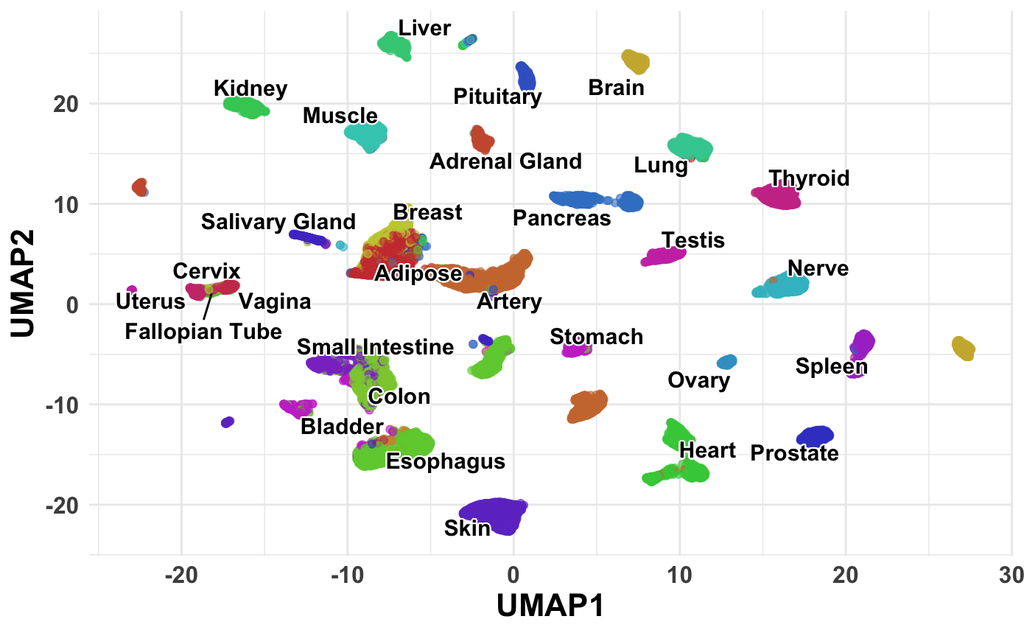

```r
# Perform UMAP with parameters for better clustering separation
set.seed(42)
pc_data <- as.matrix(pca_results$pc_scores[, 1:50])
umap_coords <- umap(pc_data, n_neighbors = 50, min_dist = 0.2, spread = 1.5, n_epochs = 500)

# Create UMAP data
umap_data <- data.table(
  UMAP1 = umap_coords[, 1],
  UMAP2 = umap_coords[, 2],
  tissue_main = pca_results$metadata$tissue_main,
  tissue_sub = pca_results$metadata$tissue_sub
)

# Calculate tissue centroids for labeling
tissue_centroids <- umap_data[, .(
  UMAP1 = median(UMAP1),
  UMAP2 = median(UMAP2)
), by = tissue_main]

# Create colors for tissues
tissue_order <- sort(unique(umap_data$tissue_main))
n_tissues <- length(tissue_order)
set.seed(123)
tissue_colors <- setNames(rainbow(n_tissues, s = 0.7, v = 0.8), tissue_order)

# Create the clean plot without elliptical boundaries
umap_plot <- ggplot(umap_data, aes(x = UMAP1, y = UMAP2, color = tissue_main)) +
  geom_point(alpha = 0.6, size = 1.5) +
  scale_color_manual(values = tissue_colors) +
  geom_text_repel(
    data = tissue_centroids,
    aes(x = UMAP1, y = UMAP2, label = tissue_main),
    size = 4, fontface = "bold", color = "black",
    bg.color = "white", bg.r = 0.1,
    inherit.aes = FALSE
  ) +
  theme_minimal() +
  labs(x = "UMAP1", y = "UMAP2") +
  theme(legend.position = "none",
        axis.title.x = element_text(size = 16, face = "bold"),
        axis.title.y = element_text(size = 16, face = "bold"),
        axis.text.x = element_text(size = 12, face = "bold"),
        axis.text.y = element_text(size = 12, face = "bold"))

# Save the plot
ggsave(file.path(output_path, "umap_plot.pdf"), umap_plot,
       width = 12, height = 10, dpi = 600, bg = "white")
print(umap_plot)
```

#—————————————————————————— # 7. Silhouette Analysis #——————————————————————————

```r
print(paste("Mean silhouette width:", round(mean(sil[,3], na.rm = TRUE), 3)))
```

```
[1] "Mean silhouette width: 0.309"
```

```r
print(paste("Median silhouette width:", round(median(sil[,3], na.rm = TRUE), 3)))
```

```
[1] "Median silhouette width: 0.503"
```

#—————————————————————————— # 8. Quality Metrics Analysis # 8.1 RIN Histogram #——————————————————————————

```r
rin_data <- merged_gtex[!is.na(SMRIN)]
rin_breaks <- seq(1, 10.5, by = 0.5)
rin_bins <- cut(rin_data$SMRIN, breaks = rin_breaks, include.lowest = TRUE, right = FALSE)
rin_counts <- as.data.frame(table(rin_bins))
names(rin_counts) <- c("bin", "count")

rin_counts$midpoint <- as.numeric(sapply(as.character(rin_counts$bin), function(x) {
  range_vals <- as.numeric(unlist(strsplit(gsub("\\[|\\)|\\[|\\]", "", x), ",")))
  return(mean(range_vals))
}))

rin_threshold <- 7.0
rin_counts$quality <- ifelse(rin_counts$midpoint < rin_threshold, "Low quality", "High quality")
# Define more intuitive colors
quality_colors <- c("High quality" = "#1f77b4",  # Blue (good/positive)
                   "Low quality" = "#ff7f0e")   # Orange (poor/negative)

names(quality_colors) <- c("High quality", "Low quality")

rin_hist <- ggplot(rin_counts, aes(x = midpoint, y = count, fill = quality)) +
  geom_bar(stat = "identity", color = "black", width = 0.5) +
# geom_text(aes(label = count), vjust = -0.3, size = 4) +
  geom_vline(xintercept = rin_threshold, linetype = "dashed", color = "black", size = 2) +
  # Add threshold label
  annotate("text", x = rin_threshold, y = 0,
           label = paste("Threshold = 7"),
           angle = 90, vjust = -0.5, hjust = -0.1, size = 6, color = "black") +
  scale_fill_manual(values = quality_colors) +
  scale_x_continuous(breaks = seq(1, 10, by = 1)) +
  scale_y_continuous(breaks = seq(0, 3500, by = 500)) +
  labs(x = "RIN Score", y = "Number of Samples",
       caption = paste0("Total samples: ", nrow(rin_data))) +
  theme_minimal() +
  theme(axis.title = element_text(size = 18, face = "bold"),
        legend.position = "top")

ggsave(file.path(output_path, "rin_histogram.pdf"), rin_hist,
       width = 12, height = 7, dpi = 300, bg = "white")
```

#—————————————————————————— # 8. Quality Metrics Analysis # 8.2 Autolysis Histogram #——————————————————————————

```r
autolysis_data <- merged_gtex[!is.na(SMATSSCR)]
autolysis_counts <- as.data.frame(table(autolysis_data$SMATSSCR))
names(autolysis_counts) <- c("value", "count")
autolysis_counts$value <- as.numeric(as.character(autolysis_counts$value))

autolysis_threshold <- 2.0
autolysis_counts$quality <- ifelse(autolysis_counts$value <= autolysis_threshold,
                                  "High quality", "Low quality")

autolysis_hist <- ggplot(autolysis_counts, aes(x = value, y = count, fill = quality)) +
  geom_bar(stat = "identity", color = "black", width = 0.95) +
# geom_text(aes(label = count), vjust = -0.5, size = 4) +
  geom_vline(xintercept = autolysis_threshold, linetype = "dashed", color = "black", size = 1) +
  annotate("text", x = autolysis_threshold, y = 0,
           label = "Threshold = 2.0",
           angle = 90, vjust = -0.5, hjust = -1, size = 4, color = "black") +
  scale_fill_manual(values = quality_colors) +
  scale_x_continuous(breaks = sort(unique(autolysis_counts$value))) +
  scale_y_continuous(breaks = seq(0, 12000, by = 2000)) +
  labs(x = "Autolysis Score", y = "Number of Samples",
       caption = paste0("Total samples: ", nrow(autolysis_data))) +
  theme_minimal() +
  theme(axis.title = element_text(size = 18, face = "bold"),
        legend.position = "top")

ggsave(file.path(output_path, "autolysis_histogram.pdf"), autolysis_hist,
       width = 12, height = 7, dpi = 300, bg = "white")
```

#—————————————————————————— # 9. Variance Analysis (ANOVA) # 9.1 RIN variance by demographics (5 factors) #——————————————————————————

```r
rin_variance <- data.frame()

# Tissue type
if("tissue_main" %in% names(rin_data)) {
  tissue_model <- aov(SMRIN ~ tissue_main, data = rin_data)
  tissue_summary <- summary(tissue_model)[[1]]
  tissue_var_explained <- tissue_summary$`Sum Sq`[1] / sum(tissue_summary$`Sum Sq`) * 100
  tissue_p_value <- tissue_summary$`Pr(>F)`[1]

  rin_variance <- rbind(rin_variance,
                       data.frame(demographic = "tissue_main",
                                 label = "Tissue Type",
                                 var_explained = tissue_var_explained,
                                 p_value = tissue_p_value))
}

# Sex
if("sex" %in% names(rin_data)) {
  sex_model <- aov(SMRIN ~ sex, data = rin_data)
  sex_summary <- summary(sex_model)[[1]]
  sex_var_explained <- sex_summary$`Sum Sq`[1] / sum(sex_summary$`Sum Sq`) * 100
  sex_p_value <- sex_summary$`Pr(>F)`[1]

  rin_variance <- rbind(rin_variance,
                       data.frame(demographic = "sex",
                                 label = "Sex",
                                 var_explained = sex_var_explained,
                                 p_value = sex_p_value))
}

# Age
if("age_range" %in% names(rin_data)) {
  age_model <- aov(SMRIN ~ age_range, data = rin_data)
  age_summary <- summary(age_model)[[1]]
  age_var_explained <- age_summary$`Sum Sq`[1] / sum(age_summary$`Sum Sq`) * 100
  age_p_value <- age_summary$`Pr(>F)`[1]

  rin_variance <- rbind(rin_variance,
                       data.frame(demographic = "age_range",
                                 label = "Age Range",
                                 var_explained = age_var_explained,
                                 p_value = age_p_value))
}

# Hardy Scale (Death Rate) - THE MISSING 5TH FACTOR
if("death_rate" %in% names(rin_data)) {
  hardy_model <- aov(SMRIN ~ death_rate, data = rin_data)
  hardy_summary <- summary(hardy_model)[[1]]
  hardy_var_explained <- hardy_summary$`Sum Sq`[1] / sum(hardy_summary$`Sum Sq`) * 100
  hardy_p_value <- hardy_summary$`Pr(>F)`[1]

  rin_variance <- rbind(rin_variance,
                       data.frame(demographic = "death_rate",
                                 label = "Hardy Scale",
                                 var_explained = hardy_var_explained,
                                 p_value = hardy_p_value))
}

# Autolysis effect on RIN
both_metrics_samples <- merged_gtex[!is.na(SMRIN) & !is.na(SMATSSCR)]
autolysis_model <- aov(SMRIN ~ SMATSSCR, data = both_metrics_samples)
autolysis_summary <- summary(autolysis_model)[[1]]
autolysis_var_explained <- autolysis_summary$`Sum Sq`[1] / sum(autolysis_summary$`Sum Sq`) * 100
autolysis_p_value <- autolysis_summary$`Pr(>F)`[1]

rin_variance <- rbind(rin_variance,
                     data.frame(demographic = "SMATSSCR",
                               label = "Autolysis Score",
                               var_explained = autolysis_var_explained,
                               p_value = autolysis_p_value))

rin_variance <- rin_variance[order(-rin_variance$var_explained),]
rin_variance$significance <- ifelse(rin_variance$p_value < 0.001, "***",
                                  ifelse(rin_variance$p_value < 0.01, "**",
                                        ifelse(rin_variance$p_value < 0.05, "*", "ns")))

# Create RIN variance plot
rin_variance_plot <- ggplot(rin_variance,
                           aes(y = reorder(label, var_explained), x = var_explained)) +
  geom_bar(stat = "identity", fill = "#66C2A5", width = 0.8) +
  # Conditional text positioning based on bar length
  geom_text(aes(label = paste0(round(var_explained, 1), "%"),
                x = ifelse(var_explained > 3, var_explained/2, var_explained),  # Middle of bar if >3%, at end if ≤3%
                hjust = ifelse(var_explained > 3, 0.5, -0.1)),  # Centered if >3%, outside if ≤3%
            size = 6, fontface = "bold", color = "black") +
  geom_text(aes(label = significance,
                x = ifelse(var_explained > 3, var_explained + 0.5, var_explained + 2)),
            hjust = 0, size = 6, color = "black") +
  labs(x = "Variance Explained (%)", y = NULL) +
  scale_x_continuous(limits = c(0, max(rin_variance$var_explained) + 4),
                     breaks = seq(0, ceiling(max(rin_variance$var_explained)/5)*5, 5)) +
  theme_minimal() +
  theme(axis.title.x = element_text(size = 18, face = "bold"),
        axis.text.y = element_text(size = 14, face = "bold"))

ggsave(file.path(output_path, "rin_variance.pdf"), rin_variance_plot,
       width = 10, height = 8, dpi = 300, bg = "white")
```

#—————————————————————————— # 9. Variance Analysis (ANOVA) # 9.2 AUTOLYSIS variance by demographics (5 factors) #——————————————————————————

```r
autolysis_variance <- data.frame()

# Tissue type
if("tissue_main" %in% names(autolysis_data)) {
  tissue_model_aut <- aov(SMATSSCR ~ tissue_main, data = autolysis_data)
  tissue_summary_aut <- summary(tissue_model_aut)[[1]]
  tissue_var_explained_aut <- tissue_summary_aut$`Sum Sq`[1] / sum(tissue_summary_aut$`Sum Sq`) * 100
  tissue_p_value_aut <- tissue_summary_aut$`Pr(>F)`[1]

  autolysis_variance <- rbind(autolysis_variance,
                             data.frame(demographic = "tissue_main",
                                       label = "Tissue Type",
                                       var_explained = tissue_var_explained_aut,
                                       p_value = tissue_p_value_aut))
}

# Sex
if("sex" %in% names(autolysis_data)) {
  sex_model_aut <- aov(SMATSSCR ~ sex, data = autolysis_data)
  sex_summary_aut <- summary(sex_model_aut)[[1]]
  sex_var_explained_aut <- sex_summary_aut$`Sum Sq`[1] / sum(sex_summary_aut$`Sum Sq`) * 100
  sex_p_value_aut <- sex_summary_aut$`Pr(>F)`[1]

  autolysis_variance <- rbind(autolysis_variance,
                             data.frame(demographic = "sex",
                                       label = "Sex",
                                       var_explained = sex_var_explained_aut,
                                       p_value = sex_p_value_aut))
}

# Age
if("age_range" %in% names(autolysis_data)) {
  age_model_aut <- aov(SMATSSCR ~ age_range, data = autolysis_data)
  age_summary_aut <- summary(age_model_aut)[[1]]
  age_var_explained_aut <- age_summary_aut$`Sum Sq`[1] / sum(age_summary_aut$`Sum Sq`) * 100
  age_p_value_aut <- age_summary_aut$`Pr(>F)`[1]

  autolysis_variance <- rbind(autolysis_variance,
                             data.frame(demographic = "age_range",
                                       label = "Age Range",
                                       var_explained = age_var_explained_aut,
                                       p_value = age_p_value_aut))
}

# Hardy Scale (Death Rate) - THE MISSING 5TH FACTOR
if("death_rate" %in% names(autolysis_data)) {
  hardy_model_aut <- aov(SMATSSCR ~ death_rate, data = autolysis_data)
  hardy_summary_aut <- summary(hardy_model_aut)[[1]]
  hardy_var_explained_aut <- hardy_summary_aut$`Sum Sq`[1] / sum(hardy_summary_aut$`Sum Sq`) * 100
  hardy_p_value_aut <- hardy_summary_aut$`Pr(>F)`[1]

  autolysis_variance <- rbind(autolysis_variance,
                             data.frame(demographic = "death_rate",
                                       label = "Hardy Scale",
                                       var_explained = hardy_var_explained_aut,
                                       p_value = hardy_p_value_aut))
}

# RIN effect on Autolysis
rin_model_aut <- aov(SMATSSCR ~ SMRIN, data = both_metrics_samples)
rin_summary_aut <- summary(rin_model_aut)[[1]]
rin_var_explained_aut <- rin_summary_aut$`Sum Sq`[1] / sum(rin_summary_aut$`Sum Sq`) * 100
rin_p_value_aut <- rin_summary_aut$`Pr(>F)`[1]

autolysis_variance <- rbind(autolysis_variance,
                           data.frame(demographic = "SMRIN",
                                     label = "RIN Score",
                                     var_explained = rin_var_explained_aut,
                                     p_value = rin_p_value_aut))

autolysis_variance <- autolysis_variance[order(-autolysis_variance$var_explained),]
autolysis_variance$significance <- ifelse(autolysis_variance$p_value < 0.001, "***",
                                         ifelse(autolysis_variance$p_value < 0.01, "**",
                                               ifelse(autolysis_variance$p_value < 0.05, "*", "ns")))

# Create Autolysis variance plot with conditional text positioning
autolysis_variance_plot <- ggplot(autolysis_variance,
                                 aes(y = reorder(label, var_explained), x = var_explained)) +
  geom_bar(stat = "identity", fill = "#FC8D62", width = 0.8) +
  # Conditional text positioning based on bar length
  geom_text(aes(label = paste0(round(var_explained, 1), "%"),
                x = ifelse(var_explained > 4, var_explained/2, var_explained),  # Middle of bar if >5%, at end if ≤5%
                hjust = ifelse(var_explained > 4, 0.5, -0.1)),  # Centered if >5%, outside if ≤5%
            size = 6, fontface = "bold", color = "black") +
  geom_text(aes(label = significance,
                x = ifelse(var_explained > 5, var_explained + 0.5, var_explained + 2)),
            hjust = 0, size = 6, color = "black") +
  labs(x = "Variance Explained (%)", y = NULL) +
  scale_x_continuous(limits = c(0, max(autolysis_variance$var_explained) + 4),
                     breaks = seq(0, ceiling(max(autolysis_variance$var_explained)/5)*5, 5)) +
  theme_minimal() +
  theme(axis.title.x = element_text(size = 18, face = "bold"),
        axis.text.y = element_text(size = 14, face = "bold"))

ggsave(file.path(output_path, "autolysis_variance.pdf"), autolysis_variance_plot,
       width = 10, height = 8, dpi = 300, bg = "white")
```

#—————————————————————————— # 9. Variance Analysis (ANOVA) # 9.3 Correlation Analysis #——————————————————————————

```r
# Calculate tissue-specific correlations
tissues <- unique(both_metrics_samples$tissue_main)
tissue_corr <- data.frame()

for (tissue in tissues) {
  tissue_samples <- both_metrics_samples[both_metrics_samples$tissue_main == tissue,]

  if (nrow(tissue_samples) >= 3) {
    cor_test <- cor.test(tissue_samples$SMRIN, tissue_samples$SMATSSCR,
                        method = "spearman", exact = FALSE)

    tissue_corr <- rbind(tissue_corr,
                        data.frame(tissue_main = tissue,
                                  correlation = cor_test$estimate,
                                  p_value = cor_test$p.value,
                                  n_samples = nrow(tissue_samples)))
  }
}

tissue_corr$significance <- ifelse(tissue_corr$p_value < 0.001, "***",
                                 ifelse(tissue_corr$p_value < 0.01, "**",
                                       ifelse(tissue_corr$p_value < 0.05, "*", "ns")))

tissue_corr <- tissue_corr[order(-abs(tissue_corr$correlation)),]
tissue_corr$tissue_label <- paste0(tissue_corr$tissue_main, " (", tissue_corr$n_samples, ")")

# Create correlation plot
correlation_plot <- ggplot(tissue_corr,
          aes(x = reorder(tissue_label, correlation), y = correlation)) +
  coord_flip() +
  geom_bar(stat = "identity", aes(fill = correlation), width = 0.7) +
  scale_fill_gradient2(low = "#E6A945", mid = "#FFFFFF", high = "#45D5E6",
                      midpoint = 0, name = "Correlation") +
  geom_text(aes(label = round(correlation, 2), y = correlation/2),
            color = "black", size = 4, fontface = "bold") +
  geom_text(aes(label = significance,
                y = ifelse(correlation >= 0, correlation + 0.03, correlation - 0.03)),
            color = "black", size = 5) +
  labs(y = "Spearman Correlation Coefficient", x = NULL) +
  theme_minimal() +
  theme(legend.position = "top",
        axis.text.y = element_text(size = 18, margin = margin(r = 5), lineheight = 0.7))

ggsave(file.path(output_path, "correlation_Variance.pdf"), correlation_plot,
       width = 11, height = 9, dpi = 300, bg = "white")
```

#—————————————————————————— # 9. Variance Analysis (ANOVA) # 9.4 Age-Related Correlations with Tissue Quality #——————————————————————————

```r
# Calculate age correlations with RIN by tissue
age_rin_correlations <- data.frame()

for(tissue in unique(rin_data$tissue_main)) {
  tissue_subset <- rin_data[rin_data$tissue_main == tissue, ]

  if(nrow(tissue_subset) >= 10) {
    # Convert age_range to numeric (use midpoint of ranges)
    tissue_subset$age_numeric <- case_when(
      tissue_subset$age_range == "20-29" ~ 25,
      tissue_subset$age_range == "30-39" ~ 35,
      tissue_subset$age_range == "40-49" ~ 45,
      tissue_subset$age_range == "50-59" ~ 55,
      tissue_subset$age_range == "60-69" ~ 65,
      tissue_subset$age_range == "70-79" ~ 75,
      TRUE ~ NA_real_
    )

    cor_test <- cor.test(tissue_subset$age_numeric, tissue_subset$SMRIN,
                        method = "spearman", exact = FALSE)

    age_rin_correlations <- rbind(age_rin_correlations,
                                 data.frame(
                                   tissue_main = tissue,
                                   correlation = cor_test$estimate,
                                   p_value = cor_test$p.value,
                                   n_samples = nrow(tissue_subset)
                                 ))
  }
}

age_rin_correlations$significance <- ifelse(age_rin_correlations$p_value < 0.001, "***",
                                           ifelse(age_rin_correlations$p_value < 0.01, "**",
                                                 ifelse(age_rin_correlations$p_value < 0.05, "*", "ns")))

age_rin_correlations <- age_rin_correlations[order(age_rin_correlations$correlation), ]

# Create age correlation plot
age_correlation_plot <- ggplot(age_rin_correlations,
                              aes(x = reorder(tissue_main, correlation), y = correlation)) +
  geom_bar(stat = "identity", aes(fill = correlation), width = 0.7) +
  scale_fill_gradient2(low = "#E74C3C", mid = "#FFFFFF", high = "#3498DB",
                      midpoint = 0, name = "Correlation") +
  geom_text(aes(label = round(correlation, 2), y = correlation/2),
            color = "black", size = 3, fontface = "bold") +
  geom_text(aes(label = significance,
                y = ifelse(correlation >= 0, correlation + 0.03, correlation - 0.03)),
            color = "black", size = 4) +
  coord_flip() +
  labs(y = "Spearman Correlation with Age", x = NULL) +
  theme_minimal() +
  theme(axis.text.y = element_text(size = 12))

ggsave(file.path(output_path, "age_correlation_plot.pdf"), age_correlation_plot,
       width = 10, height = 8, dpi = 300, bg = "white")

# Print key findings
cat("Age-RIN Correlations:\n")
```

```
Age-RIN Correlations:
```

```r
cat("Strongest negative:", age_rin_correlations$tissue_main[1],
    "r =", round(age_rin_correlations$correlation[1], 3), "\n")
```

```
Strongest negative: Fallopian Tube r = -0.386
```

```r
cat("Strongest positive:", age_rin_correlations$tissue_main[nrow(age_rin_correlations)],
    "r =", round(age_rin_correlations$correlation[nrow(age_rin_correlations)], 3), "\n")
```

```
Strongest positive: Nerve r = 0.021
```

#—————————————————————————— # 10. Esophagus-Specific Analysis Overlaying Rin and Autolysis #——————————————————————————

```r
# Select Esophagus samples
esophagus_samples <- merged_gtex[tissue_main == "Esophagus"]

if(nrow(esophagus_samples) >= 10) {
  # Extract features and run UMAP
  feature_cols <- grep("^feature_", names(esophagus_samples), value = TRUE)
  feature_matrix <- as.matrix(esophagus_samples[, ..feature_cols])
  feature_matrix <- scale(feature_matrix[, apply(feature_matrix, 2, var) > 1e-10])

  set.seed(123)
  umap_result <- umap(feature_matrix, n_neighbors = 15, n_components = 2)

  umap_df <- data.frame(
      UMAP1 = umap_result[,1],
      UMAP2 = umap_result[,2],
      Subtype = esophagus_samples$tissue_sub,
      RIN = esophagus_samples$SMRIN,
      Autolysis = esophagus_samples$SMATSSCR
  )

  # Calculate sample counts for overlays
  total_samples <- nrow(umap_df)
  rin_available <- sum(!is.na(umap_df$RIN))
  autolysis_available <- sum(!is.na(umap_df$Autolysis))

  # Create subtype UMAP
  esophagus_labels <- c("Gastroesophageal\nJunction", "Mucosa", "Muscularis")

  custom_colors <- c(
  "Gastroesophageal Junction" = "#56B4E9",  # Light blue
  "Mucosa" = "#40E0D0",                      # Turquoise
  "Muscularis" = "#808000"                   # Olive
)

  esophagus_umap <- ggplot(umap_df, aes(x = UMAP1, y = UMAP2, color = Subtype)) +
      geom_point(size = 3, alpha = 0.7) +
      theme_minimal() +
      labs(color = "Esophagus\nSubtype",
           x = "UMAP1",
           y = "UMAP2")  +
      scale_color_manual(values = custom_colors,, labels = esophagus_labels) +
      theme(legend.position = "bottom",
            legend.title = element_text(size = 14, face = "bold"),
            legend.text = element_text(size = 12),
            axis.title = element_text(size = 16, face = "bold"),
            axis.text = element_text(size = 14),
            plot.title = element_text( NULL))

  # Create RIN overlay
  esophagus_rin <- ggplot(umap_df, aes(x = UMAP1, y = UMAP2)) +
      geom_point(aes(color = RIN), size = 3, alpha = 0.7) +
      scale_color_viridis_c(name = "RIN Score",option = "plasma", na.value = "lightgrey") +
      theme_minimal() +
      labs(x = "UMAP1",
           y = "UMAP2",
           caption = paste0("RIN data available: ", rin_available, "/", total_samples,
                           " samples (", round(rin_available/total_samples*100, 1), "%)")) +
      theme(legend.position = "right",
            legend.title = element_text(size = 14, face = "bold"),
            legend.text = element_text(size = 12),
            axis.title = element_text(size = 16, face = "bold"),
            axis.text = element_text(size = 14),
            plot.title = element_text( NULL))


  # Create Autolysis overlay
  esophagus_autolysis <- ggplot(umap_df, aes(x = UMAP1, y = UMAP2)) +
      geom_point(aes(color = Autolysis), size = 3, alpha = 0.7) +
      scale_color_viridis_c(name = "Autolysis Score", option = "inferno", na.value = "lightgrey") +
      theme_minimal() +
      labs(x = "UMAP1",
           y = "UMAP2",
           caption = paste0("Autolysis data available: ", autolysis_available, "/", total_samples,
                           " samples (", round(autolysis_available/total_samples*100, 1), "%)")) +
      theme(legend.position = "right",
            legend.title = element_text(size = 14, face = "bold"),
            legend.text = element_text(size = 12),
            axis.title = element_text(size = 16, face = "bold"),
            axis.text = element_text(size = 14),
            plot.title = element_text( NULL))




  # Save plots
  ggsave(file.path(output_path, "esophagus_umap.pdf"), esophagus_umap,
         width = 8, height = 7, dpi = 600, bg = "white")
  ggsave(file.path(output_path, "esophagus_rin.pdf"), esophagus_rin,
         width = 8, height = 7, dpi = 600, bg = "white")
  ggsave(file.path(output_path, "esophagus_autolysis.pdf"), esophagus_autolysis,
         width = 8, height = 7, dpi = 600, bg = "white")

   # Save results
   saveRDS(list(
       umap_coordinates = umap_result,
       plotting_data = umap_df,
       sample_counts = list(
         total = total_samples,
         rin_available = rin_available,
         autolysis_available = autolysis_available
       )
   ), file.path(data_path, "processed/esophagus_umap_analysis.rds"))
  }
```

#—————————————————————————— # 10.1 PERMANOVA Analysis for All Tissues and Subtypes #——————————————————————————

```r
library(vegan)

# Function to perform PERMANOVA for all tissues
analyze_all_tissues_permanova <- function(merged_gtex) {
  tissues <- unique(merged_gtex$tissue_main)
  results <- data.frame()

  for(tissue in tissues) {
    tissue_data <- merged_gtex[tissue_main == tissue & !is.na(tissue_sub)]
    subtypes <- unique(tissue_data$tissue_sub)

    if(nrow(tissue_data) < 15 | length(subtypes) < 2) next

    # Get features and scale
    feature_cols <- grep("^feature_", names(tissue_data), value = TRUE)
    features <- scale(as.matrix(tissue_data[, ..feature_cols]))
    features <- features[, apply(features, 2, var, na.rm = TRUE) > 1e-10]

    # PERMANOVA test
    dist_mat <- dist(features)
    perm_test <- adonis2(dist_mat ~ tissue_sub, data = tissue_data, permutations = 999)

    # Store results
    results <- rbind(results, data.frame(
      tissue = tissue,
      n_samples = nrow(tissue_data),
      n_subtypes = length(subtypes),
      r_squared = round(perm_test$R2[1], 4),
      r_value = round(sqrt(perm_test$R2[1]), 4),
      p_value = round(perm_test$`Pr(>F)`[1], 4),
      significant = perm_test$`Pr(>F)`[1] < 0.05
    ))
  }

  return(results[order(-results$r_squared), ])
}

# Run analysis and save
permanova_results <- analyze_all_tissues_permanova(merged_gtex)
write.csv(permanova_results, file.path(output_path, "tissue_permanova_results.csv"), row.names = FALSE)

# Show significant results
significant <- permanova_results[permanova_results$significant == TRUE, ]
print(significant)
```

|  | tissue | n_samples | n_subtypes | r_squared | r_value | p_value | significant |
| --- | --- | --- | --- | --- | --- | --- | --- |
| 8 | Brain | 842 | 2 | 0.3158 | 0.5620 | 0.001 | TRUE |
| 3 | Artery | 2456 | 3 | 0.2287 | 0.4783 | 0.001 | TRUE |
| 4 | Heart | 1354 | 2 | 0.1790 | 0.4231 | 0.001 | TRUE |
| 5 | Esophagus | 2666 | 3 | 0.1321 | 0.3634 | 0.001 | TRUE |
| 2 | Adipose | 1754 | 2 | 0.0932 | 0.3053 | 0.001 | TRUE |
| 7 | Colon | 1713 | 2 | 0.0612 | 0.2474 | 0.001 | TRUE |
| 9 | Cervix | 80 | 2 | 0.0591 | 0.2430 | 0.001 | TRUE |
| 6 | Kidney | 597 | 2 | 0.0362 | 0.1904 | 0.001 | TRUE |
| 1 | Skin | 1788 | 2 | 0.0283 | 0.1684 | 0.001 | TRUE |

#—————————————————————————— # 11. Combined Figures (merging framework figure from biorender) #——————————————————————————

[figure not shown]

#—————————————————————————— # 11.1 Figure 2 #——————————————————————————

```r
figure2_patchwork
```

[output not shown]

```r
 # Create first row: Panel A (scree plot) and Panel B (pca plot)
 first_row <- plot_grid(
   scree_plot,
   pca_plot,
   labels = c("A", "B"),
   label_size = 16,
   rel_widths = c(1, 1),
   nrow = 2,
   ncol = 1
 )

 # Create second row: Panel C (Gtex Demographic) and Panel D (lollipop plot)
 second_row <- plot_grid(
   gtex_barplot ,
   lollipop_plot,
   labels = c("C", "D"),
   label_size = 16,
   rel_widths = c(1, 1),
   nrow = 2,
   ncol = 1
 )


 # Combine all rows into the final figure
 Supplementary_combined <- plot_grid(
   first_row,
   second_row,
   ncol = 2,
   rel_heights = c(1, 1)
 )

# # Save the combined figure
 save_plot(file.path(output_path, "Supplemantary4.pdf"), Supplementary_combined,
           base_width = 16, base_height = 14, dpi = 600, bg = "white")
```

#—————————————————————————— # 12. Save Final Results #——————————————————————————

```r
# Create final summary
final_results <- list(
  metadata = list(
    completion_time = Sys.time(),
    total_samples = nrow(merged_gtex),
    tissues_count = length(unique(merged_gtex$tissue_main)),
    features_count = length(grep("^feature_", names(merged_gtex)))
  ),
  quality = list(
    rin = list(
      mean = mean(merged_gtex$SMRIN, na.rm = TRUE),
      median = median(merged_gtex$SMRIN, na.rm = TRUE),
      missing = sum(is.na(merged_gtex$SMRIN))
    ),
    autolysis = list(
      mean = mean(merged_gtex$SMATSSCR, na.rm = TRUE),
      median = median(merged_gtex$SMATSSCR, na.rm = TRUE),
      missing = sum(is.na(merged_gtex$SMATSSCR))
    )
  )
)

saveRDS(final_results, file.path(data_path, "processed/gtex_analysis_complete.rds"))

# Write completion to log
write(paste("\nAnalysis completed:", Sys.time()), log_file, append = TRUE)
message("GTEx analysis pipeline completed successfully!")
```

#—————————————————————————— # Count The Total Number of patches #——————————————————————————

```r
cat("Total patches in your analysis:", total_patches_used)
```

```
Total patches in your analysis: 30331006
```

#—————————————————————————— # Table 1: GTEx Tissue Sample Counts with RIN and Autolysis Data #——————————————————————————

```r
# Create Table 1 data
create_gtex_table1 <- function(merged_gtex) {
  # Calculate tissue-level statistics
  table1_data <- merged_gtex[, .(
    `Total Samples` = .N,
    `RIN Available` = sum(!is.na(SMRIN)),
    `RIN (%)` = round(100 * sum(!is.na(SMRIN)) / .N, 1),
    `Autolysis Available` = sum(!is.na(SMATSSCR)),
    `Autolysis (%)` = round(100 * sum(!is.na(SMATSSCR)) / .N, 1),
    `Both Available` = sum(!is.na(SMRIN) & !is.na(SMATSSCR)),
    `Both (%)` = round(100 * sum(!is.na(SMRIN) & !is.na(SMATSSCR)) / .N, 1)
  ), by = tissue_main]

  # Rename tissue column
  setnames(table1_data, "tissue_main", "Tissue Type")

  # Order by total sample size
  table1_data <- table1_data[order(-`Total Samples`)]

  # Add totals row
  totals_row <- data.table(
    `Tissue Type` = "TOTAL",
    `Total Samples` = nrow(merged_gtex),
    `RIN Available` = sum(!is.na(merged_gtex$SMRIN)),
    `RIN (%)` = round(100 * sum(!is.na(merged_gtex$SMRIN)) / nrow(merged_gtex), 1),
    `Autolysis Available` = sum(!is.na(merged_gtex$SMATSSCR)),
    `Autolysis (%)` = round(100 * sum(!is.na(merged_gtex$SMATSSCR)) / nrow(merged_gtex), 1),
    `Both Available` = sum(!is.na(merged_gtex$SMRIN) & !is.na(merged_gtex$SMATSSCR)),
    `Both (%)` = round(100 * sum(!is.na(merged_gtex$SMRIN) & !is.na(merged_gtex$SMATSSCR)) / nrow(merged_gtex), 1)
  )

  # Combine main data with totals
  table1_final <- rbind(table1_data, totals_row)

  return(table1_final)
}

# Generate Table 1
table1 <- create_gtex_table1(merged_gtex)

# Save as CSV
fwrite(table1, file.path(output_path, "Table1_GTEx_Sample_Counts.csv"))

print(table1)
```

| Tissue Type | Total Samples | RIN Available | RIN (%) | Autolysis Available | Autolysis (%) | Both Available | Both (%) |
| --- | --- | --- | --- | --- | --- | --- | --- |
| Esophagus | 2666 | 1701 | 63.8 | 1708 | 64.1 | 1688 | 63.3 |
| Artery | 2456 | 1509 | 61.4 | 1513 | 61.6 | 1509 | 61.4 |
| Skin | 1788 | 1492 | 83.4 | 1502 | 84.0 | 1488 | 83.2 |
| Adipose | 1754 | 1359 | 77.5 | 1361 | 77.6 | 1359 | 77.5 |
| Colon | 1713 | 940 | 54.9 | 1057 | 61.7 | 940 | 54.9 |
| Heart | 1354 | 967 | 71.4 | 987 | 72.9 | 962 | 71.0 |
| Muscle | 979 | 884 | 90.3 | 890 | 90.9 | 878 | 89.7 |
| Nerve | 957 | 722 | 75.4 | 724 | 75.7 | 722 | 75.4 |
| Stomach | 926 | 428 | 46.2 | 428 | 46.2 | 428 | 46.2 |
| Thyroid | 888 | 740 | 83.3 | 750 | 84.5 | 740 | 83.3 |

[output cut: 20 more lines]

```r
# Simple code to get unique tissue and subtissue counts

# Number of unique main tissues
n_main_tissues <- length(unique(merged_gtex$tissue_main))
cat("Number of unique main tissues:", n_main_tissues, "\n")

# Number of unique subtissues
n_subtissues <- length(unique(merged_gtex$tissue_sub))
cat("Number of unique subtissues:", n_subtissues, "\n")

# List the main tissues
main_tissues <- sort(unique(merged_gtex$tissue_main))
cat("\nMain tissues:\n")
print(main_tissues)

# List the subtissues
subtissues <- sort(unique(merged_gtex$tissue_sub))
cat("\nSubtissues:\n")
print(subtissues)

# One-liner summary
cat(sprintf("\nSummary: %d main tissues, %d subtissues\n", n_main_tissues, n_subtissues))
```

[output not shown]